# (una pequeña) Introducción a Excel

¿Qué es Excel?

- Programa de **hoja de cálculo** desarrollado por Microsoft
- Forma parte de la suite Microsoft Office (Word, Excel, PowerPoint, OneNote, Outlook)

¿Para qué sirve?

- Permite almacenar, **organizar y analizar datos**
- Cuenta con fórmulas para realizar cálculos y análisis estadísticos
- Permite crear gráficos, tablas dinámicas, …

En la actualidad, es una herramienta fundamental en el mundo empresarial (y académico)

Antes de empezar, una pequeña broma

[figure not shown]

Lo anterior es cierto, pero … también es cierto esto:

[figure not shown]

# Lo primero es familiarizarse con la **interfaz de Excel**

… **vamos a abrir Excel**

interfaz de Excel !! 😱 😱

[figure not shown]

[Proveniente de [aquí](https://induccion.educatic.unam.mx/mod/book/view.php?id=1003&chapterid=437)]

Conceptos básicos

|  | Descripción |
| --- | --- |
| **Celda** | Intersección de fila y columna (ej: A1) |
| **Rango** | Grupo de celdas (ej: A1:C10) |
| **Hoja** | Pestaña dentro del libro |
| **Libro** | Archivo de Excel (.xlsx) |

¿cómo cargar datos en Excel?

1. **Escribir manualmente**
2. **Copiar y pegar** (desde otras fuentes)
3. **Importar archivos**

introducción de Datos (a mano)

- Tarea
- Ayuda (I)
- Ayuda (II)

Introduce datos hasta dejar tu hoja así:

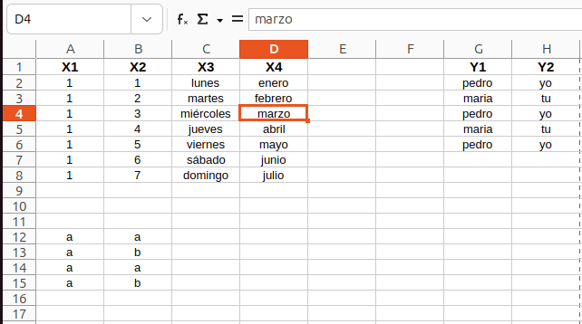

Para introducir datos …

1. Seleccionar la celda
2. Escribir el dato
3. Presionar `Enter` o `Tab`

##### Consejos:

- Para cancelar una “operación”: `Esc`

Excel puede reconocer patrones …

… y así, completar automáticamente series numéricas, fechas, días de la semana, meses, …

- ¿Cómo?
  - Escribe el primer valor (o varios) para establecer el patrón
  - Selecciona esas celda(s)
  - Posiciona el cursor en la esquina inferior derecha hasta que aparezca una cruz negra pequeña (+)
  - (y sin soltar el ratón) Arrastra hacia la dirección deseada
- También se puede hacer con “Doble click” (si hay columna adyacente)

¿cómo moverse por por una hoja de Excel?

Navegación y movimiento

| Acción | Tecla(s) |
| --- | --- |
| Desplazamiento (celda por celda) | **Flechas** |
| Ir al inicio (a A1) | **Ctrl + Inicio** |
| Ir a la última celda con datos | **Ctrl + End** |
| Moverte a la primera celda de la **fila actual** | **Inicio** |
| Salta al final o al inicio **de un rango de datos** (en la columna o fila actual) | **Ctrl + Flecha** |

| Acción | Tecla(s) |
| --- | --- |
| Desplazarse una pantalla arriba/abajo | **AvPag/RePag** |
| Desplazarse una pantalla izquierda/derecha | **Alt + AvPag/RePag** |
| Cambiar entre hojas de trabajo | **Ctrl + AvPag/RePag** |

Documentación oficial [aquí](https://support.microsoft.com/es-es/office/desplazarse-por-una-hoja-de-c%C3%A1lculo-06fc34b8-64bb-4d78-9b62-34656d700f82)

Selección de Datos

| Acción | Tecla(s) |
| --- | --- |
| Seleccionar una celda | Click simple (o escribimos las coordenadas en “Cuadro de nombres”) |
| Selec. **varias celdas (rango discontinuo)** | CRTL + Click |
| Selec. **varias celdas (rango continuo)** | SHIFT + Click (o arrastrar) |
| Fila completa | Click en el número de fila |
| Columna completa | Click en la letra de columna |

| Acción | Tecla(s) |
| --- | --- |
| Selec. rango celda por celda | **Shift** + Flechas |
| Selec. hasta el final de un rango de datos | **Ctrl + Shift** + Flechas |
| Selec. desde la posición actual hasta el inicio de la fila | **Shift + Inicio** |
| Selec. desde la posición actual hasta A1 | **Ctrl + Shift + Inicio** |
| Selec. desde la posición actual hasta la última celda con datos | **Ctrl + Shift + End** |
| Selecc. todas las celdas con datos | Ir a A1 y **Ctrl + Shift + End** |

al introducir datos es muy útil **Copiar y Pegar**

- **Ctrl+C** / **Ctrl+V**
- Click derecho → Copiar/Pegar

Pegado especial

- Solo valores
- Solo fórmulas
- Solo formato
- Trasponer, …

algunos atajos de teclado útiles

- **Ctrl+Z**: Deshacer
- **Ctrl+Y**: Rehacer

recuerda algunos de los atajos más útiles

| Atajo | Función | Descripción |
| --- | --- | --- |
| **Ctrl + C** | Copiar | Copia el texto, archivo o elemento seleccionado al portapapeles |
| **Ctrl + V** | Pegar | Pega lo que tengas copiado en el portapapeles |
| **Ctrl + X** | Cortar | Corta (mueve) el elemento seleccionado al portapapeles |
| **Ctrl + Z** | Deshacer | Deshace la última acción realizada |
| **Ctrl + Y** | Rehacer | Rehace la acción que acabas de deshacer |

# Fórmulas en Excel

- Todas las fórmulas empiezan con el signo **`=`**

Fórmulas en Excel

(todas las fórmulas empiezan con el signo `=`)

Por ejemplo:

```markdown
=5+3
=A1+B1
=A1*B1
```

Algunas funciones

Función **SUMA()**: Suma un rango de números

```markdown
=SUMA(A1:A10)
=SUMA(A1:A5, C1:C5)
=SUMA(A1, A3, A5)
```

Función **PROMEDIO()**: calcula la media (aritmética)

```markdown
=PROMEDIO(A1:A10)
=PROMEDIO(B2:B20)
```

Otras fórmulas útiles

| Función | Descripción | Ejemplo |
| --- | --- | --- |
| `MAX` | Valor máximo | `=MAX(A1:A10)` |
| `MIN` | Valor mínimo | `=MIN(A1:A10)` |
| `CONTAR` | Cuenta números | `=CONTAR(A1:A10)` |
| `SI` | Condición lógica | `=SI(A1>10,"Sí","No")` |

Práctica: crear una “tabla” simple y calcular (algunas cosas)

- Tarea
- Ayuda

Introduce estos datos en una hoja

| Producto | Cantidad | Precio |
| --- | --- | --- |
| Manzanas | 50 | 2,00 |
| Naranjas | 30 | 3,00 |
| Plátanos | 40 | 4,00 |

Has de dejarlos así:

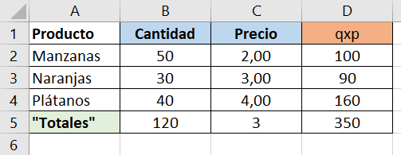

1. Primero has de copiar los datos en un hoja de Excel
2. Después has de usar ….
   - la función `SUMA()` …. y …
   - la función `PROMEDIO()` (en la columna C)

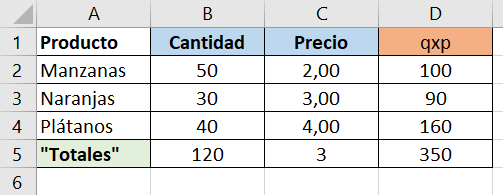

# Más cosas

… **Filtros, formatos, impresión etc….**

Organizando los datos: ordenar y filtrar

#### Ordenar

- A-Z o Z-A
- Mayor a menor
- Por varios criterios

#### Filtrar

- Mostrar solo ciertos datos
- Filtros por texto
- Filtros por números
- Filtros por fecha

Formato condicional

**Resalta celdas según condiciones:**

- Valores mayores/menores que …
- Duplicados
- Escalas de color
- Barras de datos

`Inicio > Formato condicional`

Referencias de celdas: absoluta vs. relativa

**Relativa:** `A1`

- Se ajusta al copiar o arrastar
- Ejemplo: A1, A2, A3…

**Absoluta:** `$A$1`

- NO se ajusta al copiar o arrastar
- Siempre apunta a A1
- Usar `F4` para cambiar entre relativa (libre) y absoluta (fija)

Errores comunes

| Error | Significado | Solución |
| --- | --- | --- |
| `#DIV/0!` | División entre cero | Verificar denominador |
| `#VALOR!` | Tipo de dato incorrecto | Revisar formato |
| `#REF!` | Referencia inválida | Celda eliminada |
| `#####` | Columna muy estrecha | Ampliar columna |

Protege tu trabajo

**Guardar es fundamental:**

- `Ctrl + G` → Guardar
- Guardar como… → Nueva versión

Imprimir correctamente

**Configuración de página:**

- Orientación (vertical/horizontal)
- Márgenes
- Ajustar a 1 página de ancho
- Encabezados/pies de página
- Repetir filas de título en cada página
- `Vista preliminar antes de imprimir`

# Tablas en Excel

rangos de celdas vs. tablas

Convertir un “rango formateado” en una “verdadera tabla”

Para convertir un rango en tabla has de:

1. Selecciona una celda del rango

2. Presiona `Ctrl` + `T` ó sigue la ruta de menús `Insertar > Tabla`

3. Confirma que el rango tiene encabezados

ventajas de las tablas

- ✅ Auto-formato profesional
- ✅ Filtros automáticos
- ✅ Fórmulas que se expanden solas
- ✅ Fila de totales integrada

Práctica: convierte nuestro “rango” en una tabla

- Tarea
- Ayuda
- Convierte nuestro “rango” en una tabla

| Producto | Cantidad | Precio |
| --- | --- | --- |
| Manzanas | 50 | 2,00 |
| Naranjas | 30 | 3,00 |
| Plátanos | 40 | 4,00 |

- Una vez tengas la tabla, crea una **fila de totales**
- Finalmente da formato a los precios como moneda

#### A. Convertir un rango en tabla has de:

1. Selecciona una celda del rango
2. Presiona `Ctrl` + `T` ó sigue la ruta de menús `Insertar > Tabla`
3. Confirma que el rango tiene encabezados

#### B. Para crear la fila de totales en la tabla

1. Clic en la tabla
2. `Diseño de tabla > Fila de totales`
3. En cada columna elige: SUMA, PROMEDIO, CONTAR, etc.

#### C. Formatos

1. Número / moneda / porcentaje
2. Decimales
3. Separador de miles

# Gráficos con Excel

… **Una imagen vale más que mil palabras/números**

¿Por qué usar gráficos?

- Visualizar tendencias
- Comparar valores
- Comunicar resultados
- Detectar patrones

Tipos de gráficos más comunes

| Tipo | Cuándo usarlo |
| --- | --- |
| **Líneas** | Mostrar tendencias en el tiempo |
| **Circular** | Mostrar proporciones/partes del total |
| **Columnas / Barras** | Comparar categorías |
| **X-Y** | Una variable frente a otra |